# Description

## Context

### AllLife Bank wants to focus on its credit card customer base in the next financial year. They have been advised by their marketing research team, that the penetration in the market can be improved. Based on this input, the Marketing team proposes to run personalized campaigns to target new customers as well as upsell to existing customers. Another insight from the market research was that the customers perceive the support services of the back poorly. Based on this, the Operations team wants to upgrade the service delivery model, to ensure that customer queries are resolved faster. Head of Marketing and Head of Delivery both decide to reach out to the Data Science team for help.

## Objective

### To identify different segments in the existing customer, based on their spending patterns as well as past interaction with the bank, using clustering algorithms, and provide recommendations to the bank on how to better market to and service these customers.

## Data Description

### The data provided is of various customers of a bank and their financial attributes like credit limit, the total number of credit cards the customer has, and different channels through which customers have contacted the bank for any queries (including visiting the bank, online and through a call center).

## Data Dictionary

### Sl_No: Primary key of the records

#### - Customer Key: Customer identification number

#### - Average Credit Limit: Average credit limit of each customer for all credit cards

#### - Total credit cards: Total number of credit cards possessed by the customer

#### - Total visits bank: Total number of Visits that customer made (yearly) personally to the bank

#### - Total visits online: Total number of visits or online logins made by the customer (yearly)

#### - Total calls made: Total number of calls made by the customer to the bank or its customer service department (yearly)

```python
# this will help in making the Python code more structured automatically (good coding practice)
%load_ext nb_black

# Libraries to help with reading and manipulating data
import numpy as np
import pandas as pd

# Libraries to help with data visualization
import matplotlib.pyplot as plt
import seaborn as sns

# to scale the data using z-score
from sklearn.preprocessing import StandardScaler

# to compute distances
from scipy.spatial.distance import cdist

# to perform k-means clustering and compute silhouette scores
from sklearn.cluster import KMeans
from sklearn.metrics import silhouette_score

# to visualize the elbow curve and silhouette scores
from yellowbrick.cluster import KElbowVisualizer, SilhouetteVisualizer

# to perform hierarchical clustering, compute cophenetic correlation, and create dendrograms
from sklearn.cluster import AgglomerativeClustering
from scipy.cluster.hierarchy import dendrogram, linkage, cophenet

# to compute distances
from scipy.spatial.distance import pdist

# To supress warnings
import warnings

warnings.filterwarnings("ignore")
```

```python
# loading the dataset
df = pd.read_excel("CreditCardCustomerData.xlsx")
```

# Data Overview

```python
# Observing the first five rows of the dataset.
df.head()
```

|  | Sl_No | Customer Key | Avg_Credit_Limit | Total_Credit_Cards | Total_visits_bank | Total_visits_online | Total_calls_made |
| --- | --- | --- | --- | --- | --- | --- | --- |
| 0 | 1 | 87073 | 100000 | 2 | 1 | 1 | 0 |
| 1 | 2 | 38414 | 50000 | 3 | 0 | 10 | 9 |
| 2 | 3 | 17341 | 50000 | 7 | 1 | 3 | 4 |
| 3 | 4 | 40496 | 30000 | 5 | 1 | 1 | 4 |
| 4 | 5 | 47437 | 100000 | 6 | 0 | 12 | 3 |

```python
# Observing the last five rows of the dataset.
df.tail()
```

|  | Sl_No | Customer Key | Avg_Credit_Limit | Total_Credit_Cards | Total_visits_bank | Total_visits_online | Total_calls_made |
| --- | --- | --- | --- | --- | --- | --- | --- |
| 655 | 656 | 51108 | 99000 | 10 | 1 | 10 | 0 |
| 656 | 657 | 60732 | 84000 | 10 | 1 | 13 | 2 |
| 657 | 658 | 53834 | 145000 | 8 | 1 | 9 | 1 |
| 658 | 659 | 80655 | 172000 | 10 | 1 | 15 | 0 |
| 659 | 660 | 80150 | 167000 | 9 | 0 | 12 | 2 |

```python
# Making a copy of the data set to preserve integrity
cc = df.copy()
print(f"There are {cc.shape[0]} rows and {cc.shape[1]} columns.")  # f-string
# Viewing random rows
np.random.seed(1)
cc.sample(n=10)
```

```
There are 660 rows and 7 columns.
```

|  | Sl_No | Customer Key | Avg_Credit_Limit | Total_Credit_Cards | Total_visits_bank | Total_visits_online | Total_calls_made |
| --- | --- | --- | --- | --- | --- | --- | --- |
| 547 | 548 | 38125 | 26000 | 4 | 5 | 2 | 4 |
| 353 | 354 | 94437 | 9000 | 5 | 4 | 1 | 3 |
| 499 | 500 | 65825 | 68000 | 6 | 4 | 2 | 2 |
| 173 | 174 | 38410 | 9000 | 2 | 1 | 5 | 8 |
| 241 | 242 | 81878 | 10000 | 4 | 5 | 1 | 3 |
| 341 | 342 | 70779 | 18000 | 4 | 3 | 2 | 0 |
| 647 | 648 | 79953 | 183000 | 9 | 0 | 9 | 2 |
| 218 | 219 | 28208 | 19000 | 3 | 1 | 5 | 7 |
| 120 | 121 | 16577 | 10000 | 4 | 2 | 4 | 6 |
| 134 | 135 | 31256 | 13000 | 4 | 1 | 5 | 7 |

```python
cc.describe()
```

|  | Sl_No | Customer Key | Avg_Credit_Limit | Total_Credit_Cards | Total_visits_bank | Total_visits_online | Total_calls_made |
| --- | --- | --- | --- | --- | --- | --- | --- |
| count | 660.000000 | 660.000000 | 660.000000 | 660.000000 | 660.000000 | 660.000000 | 660.000000 |
| mean | 330.500000 | 55141.443939 | 34574.242424 | 4.706061 | 2.403030 | 2.606061 | 3.583333 |
| std | 190.669872 | 25627.772200 | 37625.487804 | 2.167835 | 1.631813 | 2.935724 | 2.865317 |
| min | 1.000000 | 11265.000000 | 3000.000000 | 1.000000 | 0.000000 | 0.000000 | 0.000000 |
| 25% | 165.750000 | 33825.250000 | 10000.000000 | 3.000000 | 1.000000 | 1.000000 | 1.000000 |
| 50% | 330.500000 | 53874.500000 | 18000.000000 | 5.000000 | 2.000000 | 2.000000 | 3.000000 |
| 75% | 495.250000 | 77202.500000 | 48000.000000 | 6.000000 | 4.000000 | 4.000000 | 5.000000 |
| max | 660.000000 | 99843.000000 | 200000.000000 | 10.000000 | 5.000000 | 15.000000 | 10.000000 |

### • Customers visit the bank twice a year on average, zero being the minimum and 5 being the max.

### • Customers use online banking about three times a year on average, zero being the minimum and 15 being the max.

### • Customers contact the bank via phone about four times a year on average, minimum being zero and 10 being the max.

```python
cc.info()
```

```
<class 'pandas.core.frame.DataFrame'>
RangeIndex: 660 entries, 0 to 659
Data columns (total 7 columns):
 #   Column               Non-Null Count  Dtype
---  ------               --------------  -----
 0   Sl_No                660 non-null    int64
 1   Customer Key         660 non-null    int64
 2   Avg_Credit_Limit     660 non-null    int64
 3   Total_Credit_Cards   660 non-null    int64
 4   Total_visits_bank    660 non-null    int64
 5   Total_visits_online  660 non-null    int64
 6   Total_calls_made     660 non-null    int64
dtypes: int64(7)
memory usage: 36.2 KB
```

```python
# checking for missing values
cc.isna().sum()
```

```
Sl_No                  0
Customer Key           0
Avg_Credit_Limit       0
Total_Credit_Cards     0
Total_visits_bank      0
Total_visits_online    0
Total_calls_made       0
dtype: int64
```

```python
# let's check for duplicate observations
cc.duplicated().sum()
```

```
0
```

## We see above there are no missing values.

```python
# droppiong SI_No and Customer Key as they are redundant.
cc.drop(["Sl_No", "Customer Key"], axis=1, inplace=True)
# additional copy for hierarchical clustering later in the notebook.
cch = cc.copy()
```

```python
# Looking at data after dropping Sl_No and Customer Key.
cc.describe().T
```

|  | count | mean | std | min | 25% | 50% | 75% | max |
| --- | --- | --- | --- | --- | --- | --- | --- | --- |
| Avg_Credit_Limit | 660.0 | 34574.242424 | 37625.487804 | 3000.0 | 10000.0 | 18000.0 | 48000.0 | 200000.0 |
| Total_Credit_Cards | 660.0 | 4.706061 | 2.167835 | 1.0 | 3.0 | 5.0 | 6.0 | 10.0 |
| Total_visits_bank | 660.0 | 2.403030 | 1.631813 | 0.0 | 1.0 | 2.0 | 4.0 | 5.0 |
| Total_visits_online | 660.0 | 2.606061 | 2.935724 | 0.0 | 1.0 | 2.0 | 4.0 | 15.0 |
| Total_calls_made | 660.0 | 3.583333 | 2.865317 | 0.0 | 1.0 | 3.0 | 5.0 | 10.0 |

```python
# Printing number of count of each unique value in each column
num_cols = [
    "Total_Credit_Cards",
    "Total_visits_bank",
    "Total_visits_online",
    "Total_calls_made",
]
for column in num_cols:
    print(cc[column].value_counts())
    print("-" * 40)
```

```
4     151
6     117
7     101
5      74
2      64
1      59
3      53
10     19
8      11
9      11
Name: Total_Credit_Cards, dtype: int64
----------------------------------------
2    158
1    112
0    100
```

[output cut: 36 more lines]

## • Most customers have four, six, or seven credit cards

## • Most customers physically visited the bank once or twice. Followed by zero or three times in a year

## • Most customers utilized online services twice annually

```python
# Looking at unique values in the dataset.
cc.nunique()
```

```
Avg_Credit_Limit       110
Total_Credit_Cards      10
Total_visits_bank        6
Total_visits_online     16
Total_calls_made        11
dtype: int64
```

Total visists to the bank only has 6 unique values with the max being five and the minimum being 0, this is a good indicatior that customer service and the bank needs improvement.

# EDA

## Univariate Analysis

```python
# function to plot a boxplot and a histogram along the same scale.


def histogram_boxplot(data, feature, figsize=(12, 7), kde=False, bins=None):
    """
    Boxplot and histogram combined

    data: dataframe
    feature: dataframe column
    figsize: size of figure (default (12,7))
    kde: whether to the show density curve (default False)
    bins: number of bins for histogram (default None)
    """
    f2, (ax_box2, ax_hist2) = plt.subplots(
        nrows=2,  # Number of rows of the subplot grid= 2
        sharex=True,  # x-axis will be shared among all subplots
        gridspec_kw={"height_ratios": (0.25, 0.75)},
        figsize=figsize,
    )  # creating the 2 subplots
    sns.boxplot(
        data=data, x=feature, ax=ax_box2, showmeans=True, color="violet"
    )  # boxplot will be created and a star will indicate the mean value of the column
    sns.histplot(
        data=data, x=feature, kde=kde, ax=ax_hist2, bins=bins, palette="winter"
    ) if bins else sns.histplot(
        data=data, x=feature, kde=kde, ax=ax_hist2
    )  # For histogram
    ax_hist2.axvline(
        data[feature].mean(), color="green", linestyle="--"
    )  # Add mean to the histogram
    ax_hist2.axvline(
        data[feature].median(), color="black", linestyle="-"
    )  # Add median to the histogram
```

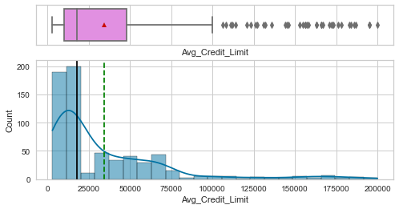

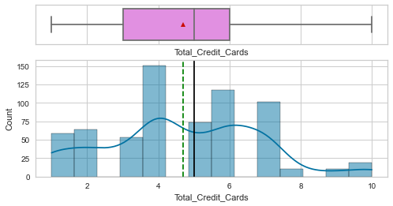

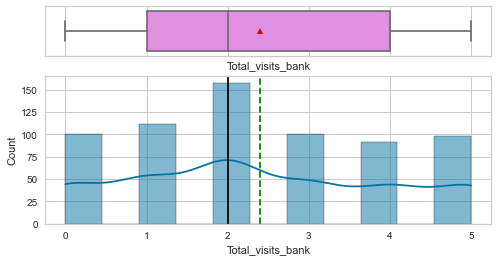

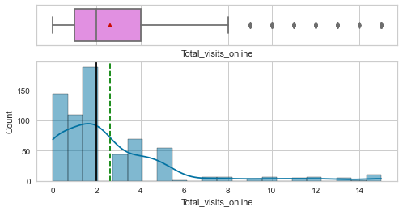

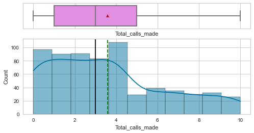

```python
# selecting numerical columns
num_col = cc.select_dtypes(include=np.number).columns.tolist()

for item in num_col:
    histogram_boxplot(cc, item, kde=True, figsize=(8, 4))
```

```python
print(num_col)
```

```
['Avg_Credit_Limit', 'Total_Credit_Cards', 'Total_visits_bank', 'Total_visits_online', 'Total_calls_made']
```

#### • Total Credit Cards is slightly skewed to the right with no outliers. The average and median are about five credit cards per customer.

#### • Total Visits Bank is also slightly skewed to the right with no outliers. The average is close two and the median is right at 2.

#### • Total Calls Made is right skewed, no outliers. Average is closer to four with the median close to three.

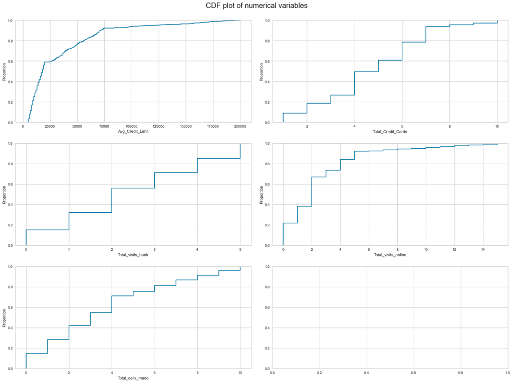

```python
fig, axes = plt.subplots(3, 2, figsize=(20, 15))
fig.suptitle("CDF plot of numerical variables", fontsize=20)
counter = 0
for ii in range(3):
    sns.ecdfplot(ax=axes[ii][0], x=cc[num_col[counter]])
    counter = counter + 1
    if counter != 5:
        sns.ecdfplot(ax=axes[ii][1], x=cc[num_col[counter]])
        counter = counter + 1
    else:
        pass

fig.tight_layout(pad=2.0)
```

#### Observations

##### • 80% of customers have 6 credit cards or less, this metric isn’t necessarily bad but does have some opportunity to be improved upon by way of better customer service.

##### • 90% of customers utilize online banking 5 times or less annually. There is a positive correlation, seen in the pair plot below, between Total Credit Cards and Average Credit Limit in respects to online banking. The marketing team needs to work on driving more customers to use online services as customers who frequent the site seem to be more satisfied than not.

```python
# function to create labeled barplots


def labeled_barplot(data, feature, perc=False, n=None):
    """
    Barplot with percentage at the top

    data: dataframe
    feature: dataframe column
    perc: whether to display percentages instead of count (default is False)
    n: displays the top n category levels (default is None, i.e., display all levels)
    """

    total = len(data[feature])  # length of the column
    count = data[feature].nunique()
    if n is None:
        plt.figure(figsize=(count + 1, 5))
    else:
        plt.figure(figsize=(n + 1, 5))

    plt.xticks(rotation=90, fontsize=15)
    ax = sns.countplot(
        data=data,
        x=feature,
        palette="Paired",
        order=data[feature].value_counts().index[:n].sort_values(),
    )

    for p in ax.patches:
        if perc:
            label = "{:.1f}%".format(
                100 * p.get_height() / total
            )  # percentage of each class of the category
        else:
            label = p.get_height()  # count of each level of the category

        x = p.get_x() + p.get_width() / 2  # width of the plot
        y = p.get_height()  # height of the plot

        ax.annotate(
            label,
            (x, y),
            ha="center",
            va="center",
            size=12,
            xytext=(0, 5),
            textcoords="offset points",
        )  # annotate the percentage

    plt.show()  # show the plot
```

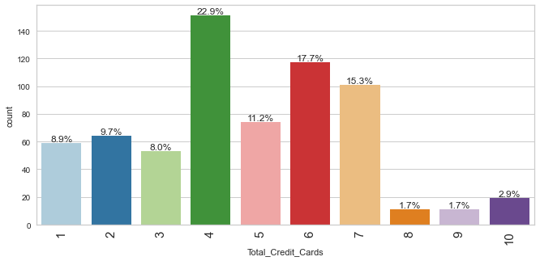

```python
# Observing total amount of credit cards held by customers.
labeled_barplot(cc, "Total_Credit_Cards", perc=True)
```

#### • Most customers hold either four or six credit cards.

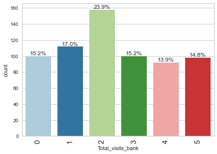

```python
# Observing Total visits to the bank.
labeled_barplot(cc, "Total_visits_bank", perc=True)
```

#### • Most customers visit the bank twice annually with much variation between other number of visits.

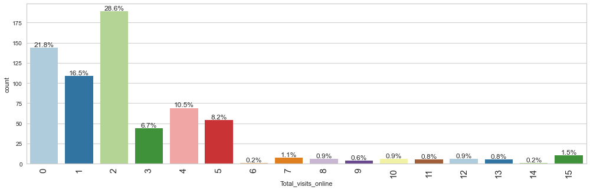

```python
# Observing Total Visits Online
labeled_barplot(cc, "Total_visits_online", perc=True)
```

#### • Most customers utilize online services twice annually followed by zero. This may indicate a poor website; either in functionality, visual appeal, or both.

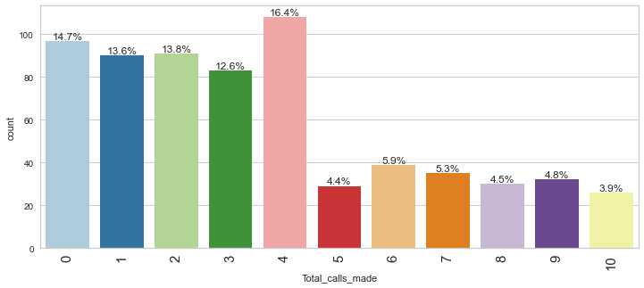

```python
# let's explore discounts further
labeled_barplot(cc, "Total_calls_made", perc=True)
```

#### • Most customer call the bank no more than four times annually. Customer service may not be able to resolve issues and/or need training on how to speak to customers to improve customer service.

## Bivariate Analysis

```python
cc.groupby(["Total_Credit_Cards",], as_index=False)["Total_visits_online"].median()
```

|  | Total_Credit_Cards | Total_visits_online |
| --- | --- | --- |
| 0 | 1 | 4 |
| 1 | 2 | 4 |
| 2 | 3 | 4 |
| 3 | 4 | 2 |
| 4 | 5 | 1 |
| 5 | 6 | 1 |
| 6 | 7 | 1 |
| 7 | 8 | 8 |
| 8 | 9 | 11 |
| 9 | 10 | 12 |

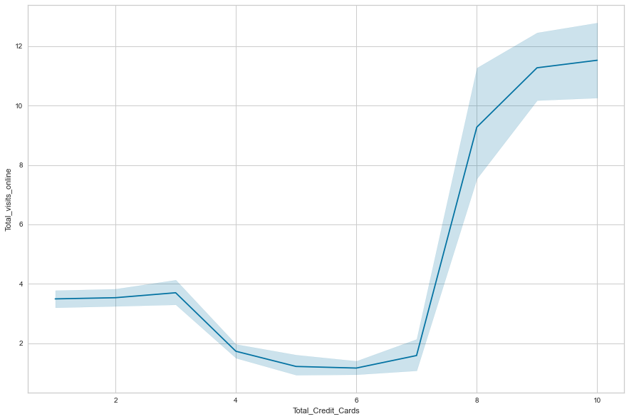

```python
# Shows the correlation between Total Visits Online and Total Credit Cards
plt.figure(figsize=(15, 10))
sns.lineplot(x="Total_Credit_Cards", y="Total_visits_online", data=cc)
plt.show()
```

```python
cc.groupby(["Total_Credit_Cards"], as_index=False)["Total_calls_made"].median()
```

|  | Total_Credit_Cards | Total_calls_made |
| --- | --- | --- |
| 0 | 1 | 7.0 |
| 1 | 2 | 6.5 |
| 2 | 3 | 6.0 |
| 3 | 4 | 3.0 |
| 4 | 5 | 2.0 |
| 5 | 6 | 2.0 |
| 6 | 7 | 2.0 |
| 7 | 8 | 1.0 |
| 8 | 9 | 2.0 |
| 9 | 10 | 1.0 |

#### The chart above and graph below show that total credit cards held by customers decrease as customers communication with the bank via phone increase.

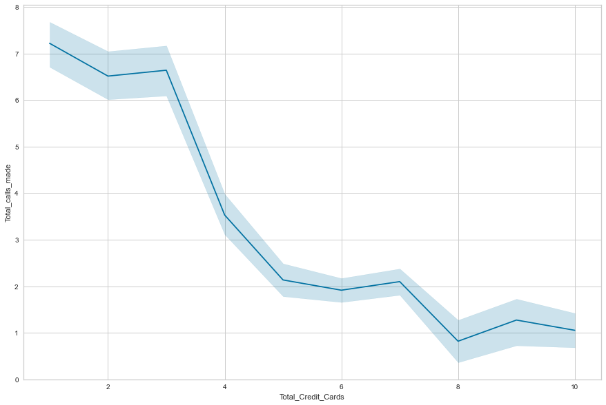

```python
# Shows the correlation between Total Calls Made and Total Credit Cards.
plt.figure(figsize=(15, 10))
sns.lineplot(x="Total_Credit_Cards", y="Total_calls_made", data=cc)
plt.show()
```

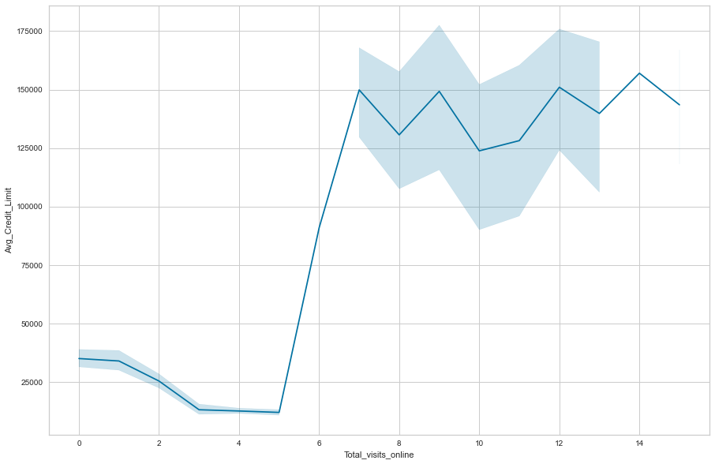

```python
# Shows the correlation between Total Visits Online and Average Credit Limit
plt.figure(figsize=(15, 10))
sns.lineplot(x="Total_visits_online", y="Avg_Credit_Limit", data=cc)
plt.show()
```

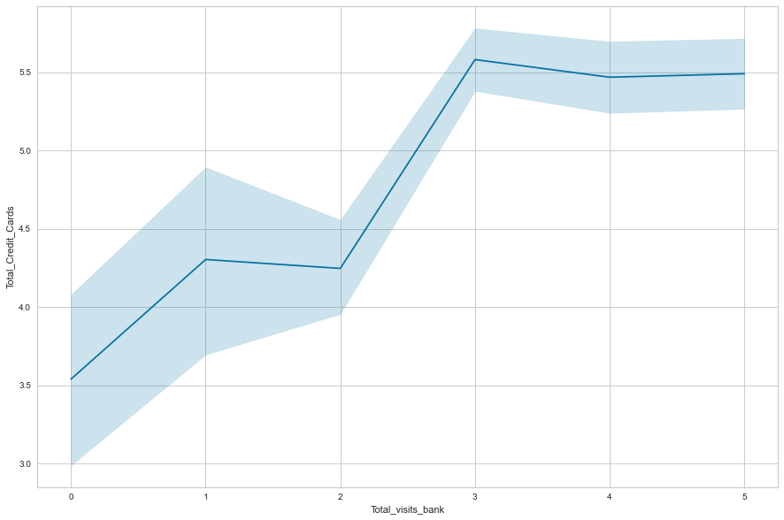

```python
# Shows the correlation between Total Bank Visits and Total Credit Cards
plt.figure(figsize=(15, 10))
sns.lineplot(x="Total_visits_bank", y="Total_Credit_Cards", data=cc)
plt.show()
```

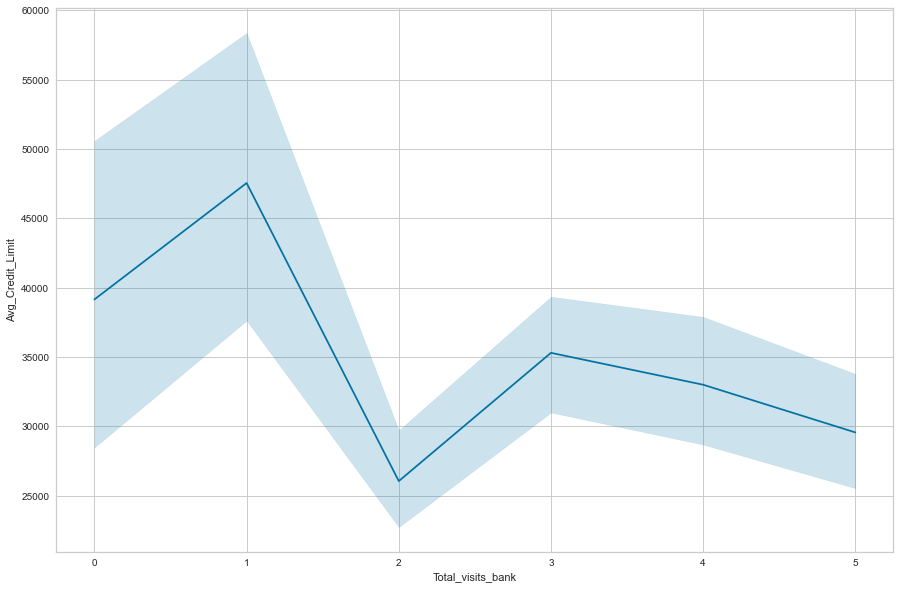

```python
# Shows the correlation between Total Bank Visits and Total Credit Cards
plt.figure(figsize=(15, 10))
sns.lineplot(x="Total_visits_bank", y="Avg_Credit_Limit", data=cc)
plt.show()
```

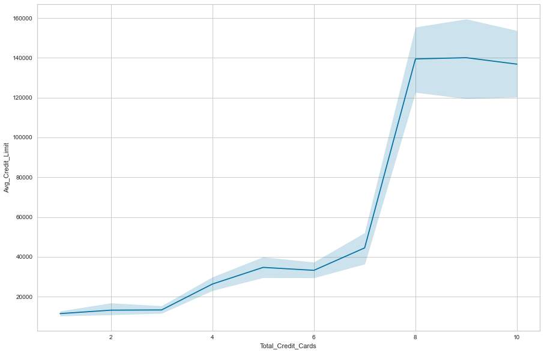

```python
# Shows the correlation between Average Credit Limit and Total Credit Cards
plt.figure(figsize=(15, 10))
sns.lineplot(x="Total_Credit_Cards", y="Avg_Credit_Limit", data=cc)
plt.show()
```

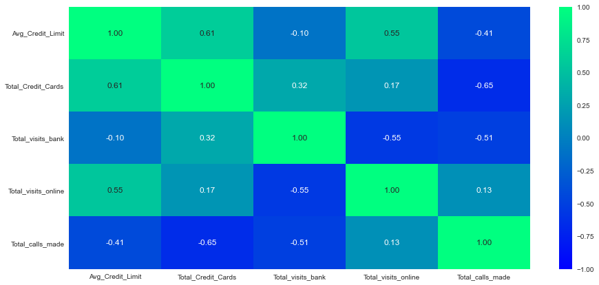

```python
plt.figure(figsize=(15, 7))
sns.heatmap(df[num_col].corr(), annot=True, vmin=-1, vmax=1, fmt=".2f", cmap="winter")
plt.show()
```

### Observations

#### • Average Credit Limit and Total Credit Cards are positively correlated. These customers may be higher earners and have good credit score, hence the high limits and amounts of credit cards they hold.

#### • Total Credit Cards is negatively correlated with Total call Made. This could mean that the customer service department is either not good and upselling credit cards to customers, or do a poor job of resolving issues, causing customers to close accounts.

#### • Total visits Bank is negatively correlated with Total calls made and Total visits online. This may indicate bad in person interaction with bank staff turns customers away from calling into the bank and/or using online services.

#### • Total visits online have some positive correlation with Average Credit Limit

#### • Total calls made is negatively correlated with Total visits bank, Total Credit Cards, and Avg Credit Limit; customer service is doing a very poor job satisfying customers.

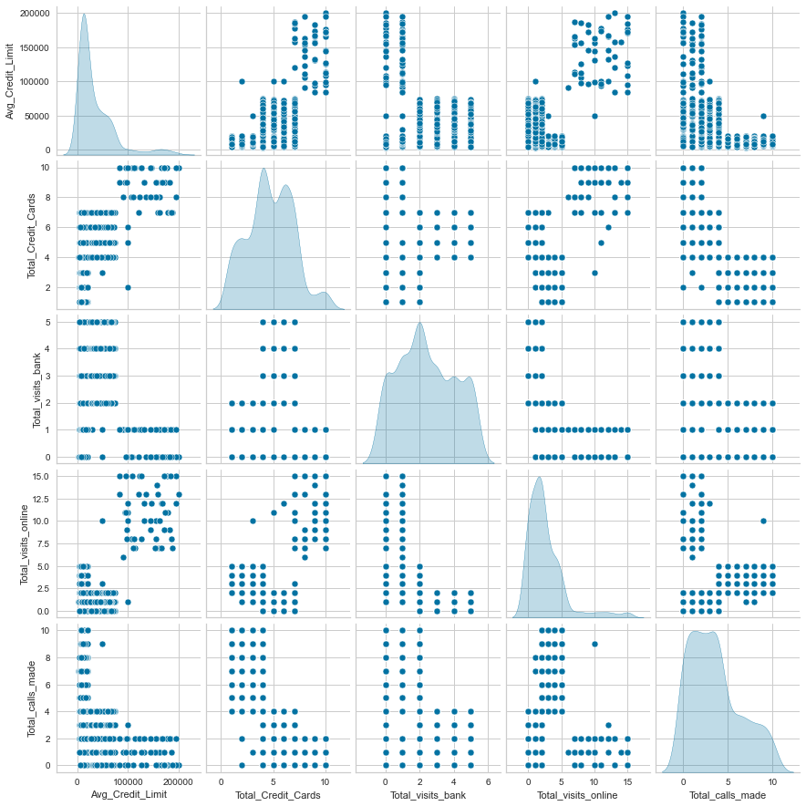

```python
sns.pairplot(data=df[num_col], diag_kind="kde")
plt.show()
```

## Observations

• Average Credit Limit is right skewed.

• Total Credit Cards is slightly right skewed.

• Total visits online are right skewed.

• Total calls made is right skewed.

# Data Preprocessing

```python
# variables used for clustering
num_col
```

```
['Avg_Credit_Limit',
 'Total_Credit_Cards',
 'Total_visits_bank',
 'Total_visits_online',
 'Total_calls_made']
```

```python
# scaling the dataset before clustering
scaler = StandardScaler()
subset = df[num_col].copy()
subset_scaled = scaler.fit_transform(subset)
```

```python
subset_scaled
```

```
array([[ 1.74018685, -1.24922476, -0.86045063, -0.54748969, -1.25153737],
       [ 0.41029254, -0.78758515, -1.47373077,  2.5205186 ,  1.89185881],
       [ 0.41029254,  1.05897329, -0.86045063,  0.13428993,  0.1455276 ],
       ...,
       [ 2.93709172,  1.5206129 , -0.86045063,  2.17962879, -0.90227113],
       [ 3.65523464,  2.44389211, -0.86045063,  4.22496765, -1.25153737],
       [ 3.52224521,  1.9822525 , -1.47373077,  3.20229822, -0.55300488]])
```

```python
# creating a dataframe of the scaled columns
subset_scaled_df = pd.DataFrame(subset_scaled, columns=subset.columns)
```

## K-means Clustering

```
Number of Clusters: 1 	Average Distortion: 2.0069222262503614
Number of Clusters: 2 	Average Distortion: 1.4571553548514269
Number of Clusters: 3 	Average Distortion: 1.1466276549150365
Number of Clusters: 4 	Average Distortion: 1.0463825294774465
Number of Clusters: 5 	Average Distortion: 0.990772333470802
Number of Clusters: 6 	Average Distortion: 0.9430843103448057
Number of Clusters: 7 	Average Distortion: 0.9094290022428964
Number of Clusters: 8 	Average Distortion: 0.8891380888508975
```

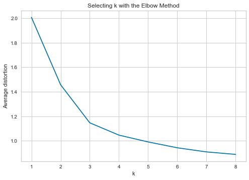

```python
clusters = range(1, 9)
meanDistortions = []

for k in clusters:
    model = KMeans(n_clusters=k)
    model.fit(subset_scaled_df)
    prediction = model.predict(subset_scaled_df)
    distortion = (
        sum(
            np.min(cdist(subset_scaled_df, model.cluster_centers_, "euclidean"), axis=1)
        )
        / subset_scaled_df.shape[0]
    )

    meanDistortions.append(distortion)

    print("Number of Clusters:", k, "\tAverage Distortion:", distortion)

plt.plot(clusters, meanDistortions, "bx-")
plt.xlabel("k")
plt.ylabel("Average distortion")
plt.title("Selecting k with the Elbow Method")
plt.show()
```

#### A good value for k appers to be 4 or 5.

#### Below we will cross reference out recommendation for k by checking the silhouette scores.

```
For n_clusters = 2, the silhouette score is 0.41842496663215445)
For n_clusters = 3, the silhouette score is 0.5157182558881063)
For n_clusters = 4, the silhouette score is 0.3556670619372605)
For n_clusters = 5, the silhouette score is 0.2717470361089752)
For n_clusters = 6, the silhouette score is 0.2560150493463967)
For n_clusters = 7, the silhouette score is 0.2484780407682755)
For n_clusters = 8, the silhouette score is 0.2261268477139729)
For n_clusters = 9, the silhouette score is 0.21993804286643806)
```

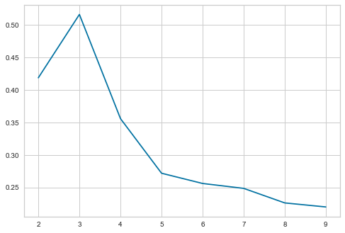

```python
sil_score = []
cluster_list = list(range(2, 10))
for n_clusters in cluster_list:
    clusterer = KMeans(n_clusters=n_clusters)
    preds = clusterer.fit_predict((subset_scaled_df))
    # centers = clusterer.cluster_centers_
    score = silhouette_score(subset_scaled_df, preds)
    sil_score.append(score)
    print("For n_clusters = {}, the silhouette score is {})".format(n_clusters, score))

plt.plot(cluster_list, sil_score)
plt.show()
```

#### The chart above shows us the silhouette score for 3 clusters is higher than that for 4 or 5 clusters; as a result, before making 4 the value of k we will explore a bit more.

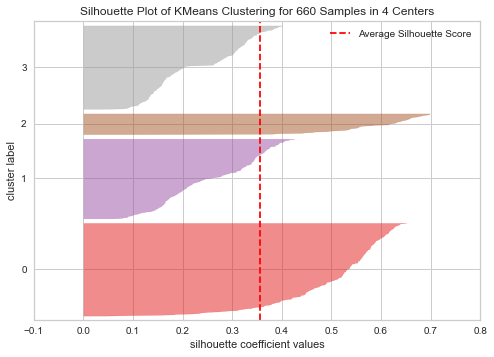

```python
# Visualizing the silhouette coefficients for k as 4
visualizer = SilhouetteVisualizer(KMeans(4, random_state=1))
visualizer.fit(subset_scaled_df)
visualizer.show()
```

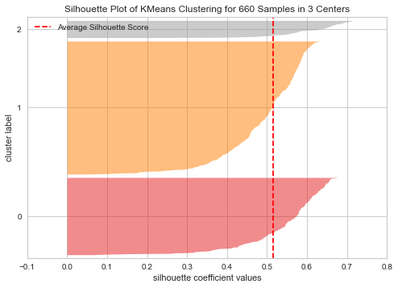

```python
# Visualizing the silhouette coefficients for k as 3
visualizer = SilhouetteVisualizer(KMeans(3, random_state=1))
visualizer.fit(subset_scaled_df)
visualizer.show()
```

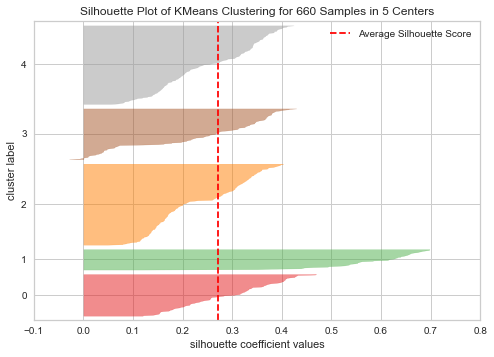

```python
# Visualizing the silhouette coefficients for k as 5
visualizer = SilhouetteVisualizer(KMeans(5, random_state=1))
visualizer.fit(subset_scaled_df)
visualizer.show()
```

#### From the silhouette scores and visuals above 3 is the best value for k, we will proceed with 3.

```python
# Taking 3 as the number of clusters.
kmeans = KMeans(n_clusters=3, random_state=0)
kmeans.fit(subset_scaled_df)
```

```
KMeans(n_clusters=3, random_state=0)
```

```python
# adding kmeans cluster labels to the original and scaled dataframes
cc["K_means_segments"] = kmeans.labels_
subset_scaled_df["K_means_segments"] = kmeans.labels_
```

## Cluster Profiling

```python
cluster_profile_k = cc.groupby("K_means_segments").mean()
```

```python
cluster_profile_k["count_in_each_segments"] = (
    cc.groupby("K_means_segments")["Total_Credit_Cards"].count().values
)
```

```python
# Looking at cluster profiles
cluster_profile_k.style.highlight_max(color="lightgreen", axis=0)
```

| K_means_segments | Avg_Credit_Limit | Total_Credit_Cards | Total_visits_bank | Total_visits_online | Total_calls_made | count_in_each_segments |
| --- | --- | --- | --- | --- | --- | --- |
| 0 | 33782.383420 | 5.515544 | 3.489637 | 0.981865 | 2.000000 | 386 |
| 1 | 12174.107143 | 2.410714 | 0.933036 | 3.553571 | 6.870536 | 224 |
| 2 | 141040.000000 | 8.740000 | 0.600000 | 10.900000 | 1.080000 | 50 |

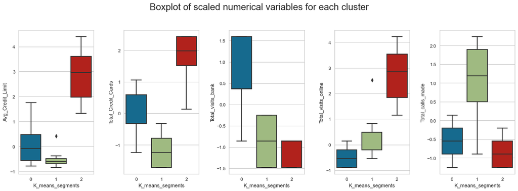

```python
fig, axes = plt.subplots(1, 5, figsize=(16, 6))
fig.suptitle("Boxplot of scaled numerical variables for each cluster", fontsize=20)
counter = 0
for ii in range(5):
    sns.boxplot(
        ax=axes[ii],
        y=subset_scaled_df[num_col[counter]],
        x=subset_scaled_df["K_means_segments"],
    )
    counter = counter + 1

fig.tight_layout(pad=2.0)
```

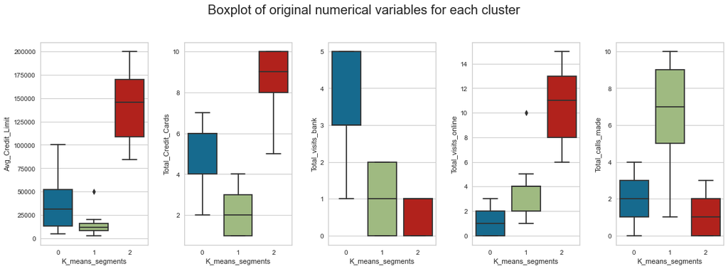

```python
fig, axes = plt.subplots(1, 5, figsize=(16, 6))
fig.suptitle("Boxplot of original numerical variables for each cluster", fontsize=20)
counter = 0
for ii in range(5):
    sns.boxplot(ax=axes[ii], y=cc[num_col[counter]], x=cc["K_means_segments"])
    counter = counter + 1

fig.tight_layout(pad=2.0)
```

## Hierarchical Clustering

```python
# list of distance metrics
distance_metrics = ["euclidean", "chebyshev", "mahalanobis", "cityblock"]

# list of linkage methods
linkage_methods = ["single", "complete", "average", "weighted"]

high_cophenet_corr = 0
high_dm_lm = [0, 0]

for dm in distance_metrics:
    for lm in linkage_methods:
        Z = linkage(subset_scaled_df, metric=dm, method=lm)
        c, coph_dists = cophenet(Z, pdist(subset_scaled_df))
        print(
            "Cophenetic correlation for {} distance and {} linkage is {}.".format(
                dm.capitalize(), lm, c
            )
        )
        if high_cophenet_corr < c:
            high_cophenet_corr = c
            high_dm_lm[0] = dm
            high_dm_lm[1] = lm
```

```
Cophenetic correlation for Euclidean distance and single linkage is 0.8788676940541079.
Cophenetic correlation for Euclidean distance and complete linkage is 0.8860521900934342.
Cophenetic correlation for Euclidean distance and average linkage is 0.9168725782090766.
Cophenetic correlation for Euclidean distance and weighted linkage is 0.9133393931042242.
Cophenetic correlation for Chebyshev distance and single linkage is 0.8978014062578786.
Cophenetic correlation for Chebyshev distance and complete linkage is 0.8623270916886306.
Cophenetic correlation for Chebyshev distance and average linkage is 0.9160784250471772.
Cophenetic correlation for Chebyshev distance and weighted linkage is 0.9109044268579872.
Cophenetic correlation for Mahalanobis distance and single linkage is 0.8959952526724232.
Cophenetic correlation for Mahalanobis distance and complete linkage is 0.6550023123197846.
Cophenetic correlation for Mahalanobis distance and average linkage is 0.8467618899578894.
Cophenetic correlation for Mahalanobis distance and weighted linkage is 0.820791716282288.
Cophenetic correlation for Cityblock distance and single linkage is 0.8406488764445825.
Cophenetic correlation for Cityblock distance and complete linkage is 0.8890360877047411.
Cophenetic correlation for Cityblock distance and average linkage is 0.9149250127652871.
Cophenetic correlation for Cityblock distance and weighted linkage is 0.8901622514742297.
```

```python
# printing the combination of distance metric and linkage method with the highest cophenetic correlation
print(
    "Highest cophenetic correlation is {}, which is obtained with {} distance and {} linkage.".format(
        high_cophenet_corr, high_dm_lm[0].capitalize(), high_dm_lm[1]
    )
)
```

```
Highest cophenetic correlation is 0.9168725782090766, which is obtained with Euclidean distance and average linkage.
```

#### Looking at linkage methods with Euclidean distance only.

```python
%%time
# list of linkage methods
linkage_methods = ["single", "complete", "average", "centroid", "ward", "weighted"]

high_cophenet_corr = 0
high_dm_lm = [0, 0]

for lm in linkage_methods:
    Z = linkage(subset_scaled_df, metric="euclidean", method=lm)
    c, coph_dists = cophenet(Z, pdist(subset_scaled_df))
    print("Cophenetic correlation for {} linkage is {}.".format(lm, c))
    if high_cophenet_corr < c:
        high_cophenet_corr = c
        high_dm_lm[0] = "euclidean"
        high_dm_lm[1] = lm
```

```
Cophenetic correlation for single linkage is 0.8788676940541079.
Cophenetic correlation for complete linkage is 0.8860521900934342.
Cophenetic correlation for average linkage is 0.9168725782090766.
Cophenetic correlation for centroid linkage is 0.9134704636213649.
Cophenetic correlation for ward linkage is 0.774233615737438.
Cophenetic correlation for weighted linkage is 0.9133393931042242.
Wall time: 121 ms
```

```python
# printing the combination of distance metric and linkage method with the highest cophenetic correlation
print(
    "Highest cophenetic correlation is {}, which is obtained with {} linkage.".format(
        high_cophenet_corr, high_dm_lm[1]
    )
)
```

```
Highest cophenetic correlation is 0.9168725782090766, which is obtained with average linkage.
```

#### Observations

- The Cophenetic Correlation is at maximum with Euclidean Distance and Average Linkage.

#### Visualizing dendrograms for the different linkage methods using Euclidean Distance.

```
Wall time: 4.83 s
```

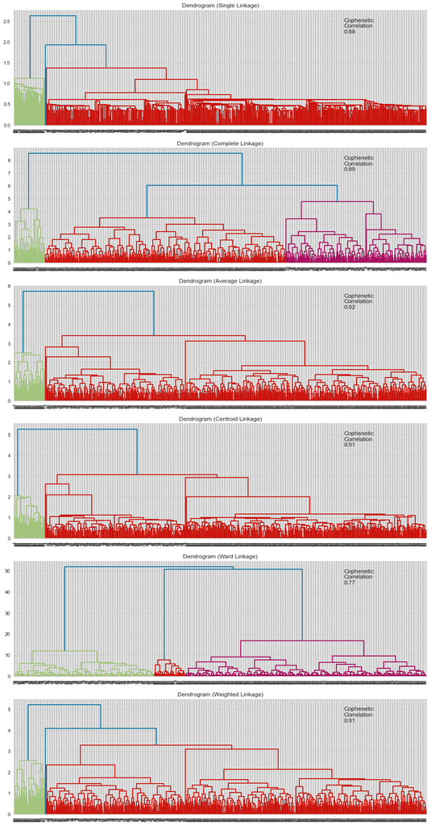

```python
%%time
# list of linkage methods
linkage_methods = ["single", "complete", "average", "centroid", "ward", "weighted"]

# lists to save results of cophenetic correlation calculation
compare_cols = ["Linkage", "Cophenetic Coefficient"]
compare = []

# to create a subplot image
fig, axs = plt.subplots(len(linkage_methods), 1, figsize=(15, 30))

# We will enumerate through the list of linkage methods above
# For each linkage method, we will plot the dendrogram and calculate the cophenetic correlation
for i, method in enumerate(linkage_methods):
    Z = linkage(subset_scaled_df, metric="euclidean", method=method)

    dendrogram(Z, ax=axs[i])
    axs[i].set_title(f"Dendrogram ({method.capitalize()} Linkage)")

    coph_corr, coph_dist = cophenet(Z, pdist(subset_scaled_df))
    axs[i].annotate(
        f"Cophenetic\nCorrelation\n{coph_corr:0.2f}",
        (0.80, 0.80),
        xycoords="axes fraction",
    )

    compare.append([method, coph_corr])
```

#### Observations

- The Dengrogram for Average Linkage shows dinstinct clusters. We will analyze further below.

```python
# let's create a dataframe to compare cophenetic correlations for each linkage method
df_cc = pd.DataFrame(compare, columns=compare_cols)
df_cc
```

|  | Linkage | Cophenetic Coefficient |
| --- | --- | --- |
| 0 | single | 0.878868 |
| 1 | complete | 0.886052 |
| 2 | average | 0.916873 |
| 3 | centroid | 0.913470 |
| 4 | ward | 0.774234 |
| 5 | weighted | 0.913339 |

##### Again we see Average Linkage with the highest score, followed closely by Centroid and Weighted.

```
Wall time: 3.19 s
```

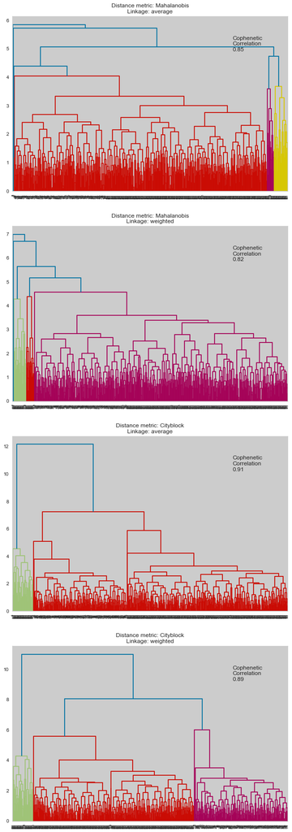

```python
%%time
# list of distance metrics
distance_metrics = ["mahalanobis", "cityblock"]

# list of linkage methods
linkage_methods = ["average", "weighted"]

# to create a subplot image
fig, axs = plt.subplots(
    len(distance_metrics) + len(distance_metrics), 1, figsize=(10, 30)
)

i = 0
for dm in distance_metrics:
    for lm in linkage_methods:
        Z = linkage(subset_scaled_df, metric=dm, method=lm)

        dendrogram(Z, ax=axs[i])
        axs[i].set_title("Distance metric: {}\nLinkage: {}".format(dm.capitalize(), lm))

        coph_corr, coph_dist = cophenet(Z, pdist(subset_scaled_df))
        axs[i].annotate(
            f"Cophenetic\nCorrelation\n{coph_corr:0.2f}",
            (0.80, 0.80),
            xycoords="axes fraction",
        )
        i += 1
```

#### Observations

- Out of all dendrograms the one with Cityblock(Manhattan) Distance with Average Linkage gave us separate and distinct clusters.
  - Three is the appropriate number of clusters from the dendrogram with Average Linkage method.
    - We will use Cityblock with Average Linkage for Hierarchical Clustering; it has a good Cophenetic score and well defined clusters.

```python
HCmodel = AgglomerativeClustering(n_clusters=3, affinity="cityblock", linkage="average")
HCmodel.fit(subset_scaled_df)
```

```
AgglomerativeClustering(affinity='cityblock', linkage='average', n_clusters=3)
```

```python
# adding hierarchical cluster labels to the original and scaled dataframes
subset_scaled_df["HC_Clusters"] = HCmodel.labels_
cch["HC_Clusters"] = HCmodel.labels_
```

## Cluster Profiling

```python
cluster_profile_h = cch.groupby("HC_Clusters").mean()
```

```python
cluster_profile_h["count_in_each_segments"] = (
    cch.groupby("HC_Clusters")["Total_Credit_Cards"].count().values
)
```

```python
# let's display cluster profiles
cluster_profile_h.style.highlight_max(color="lightgreen", axis=0)
```

| HC_Clusters | Avg_Credit_Limit | Total_Credit_Cards | Total_visits_bank | Total_visits_online | Total_calls_made | count_in_each_segments |
| --- | --- | --- | --- | --- | --- | --- |
| 0 | 33782.383420 | 5.515544 | 3.489637 | 0.981865 | 2.000000 | 386 |
| 1 | 141040.000000 | 8.740000 | 0.600000 | 10.900000 | 1.080000 | 50 |
| 2 | 12174.107143 | 2.410714 | 0.933036 | 3.553571 | 6.870536 | 224 |

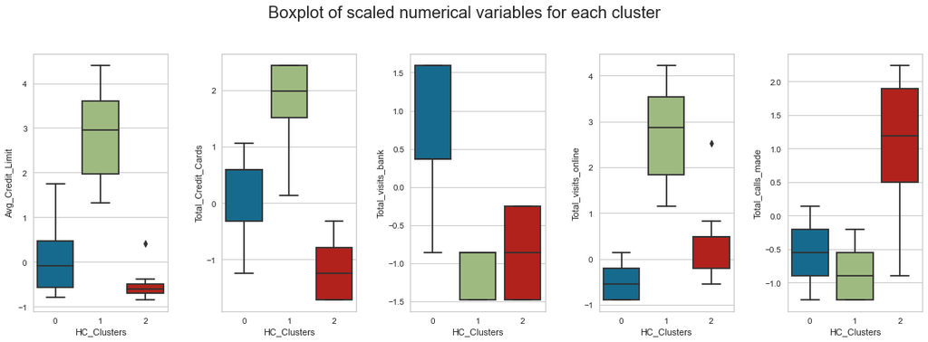

```python
fig, axes = plt.subplots(1, 5, figsize=(16, 6))
fig.suptitle("Boxplot of scaled numerical variables for each cluster", fontsize=20)
counter = 0
for ii in range(5):
    sns.boxplot(
        ax=axes[ii],
        y=subset_scaled_df[num_col[counter]],
        x=subset_scaled_df["HC_Clusters"],
    )
    counter = counter + 1

fig.tight_layout(pad=2.0)
```

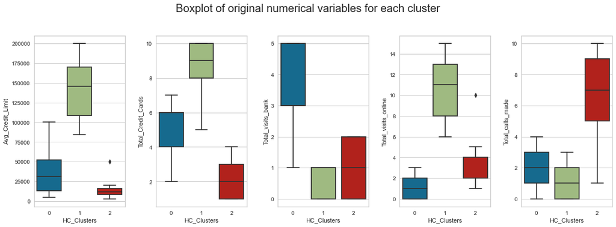

```python
fig, axes = plt.subplots(1, 5, figsize=(16, 6))
fig.suptitle("Boxplot of original numerical variables for each cluster", fontsize=20)
counter = 0
for ii in range(5):
    sns.boxplot(ax=axes[ii], y=cch[num_col[counter]], x=cch["HC_Clusters"])
    counter = counter + 1

fig.tight_layout(pad=2.0)
```

# K-means and Hierarchical Clustering Comparison

### K-means Cluster Profile

```python
cluster_profile_k.style.highlight_max(color="lightgreen", axis=0)
```

| K_means_segments | Avg_Credit_Limit | Total_Credit_Cards | Total_visits_bank | Total_visits_online | Total_calls_made | count_in_each_segments |
| --- | --- | --- | --- | --- | --- | --- |
| 0 | 33782.383420 | 5.515544 | 3.489637 | 0.981865 | 2.000000 | 386 |
| 1 | 12174.107143 | 2.410714 | 0.933036 | 3.553571 | 6.870536 | 224 |
| 2 | 141040.000000 | 8.740000 | 0.600000 | 10.900000 | 1.080000 | 50 |

### Hierarchical Cluster Profile

```python
cluster_profile_h.style.highlight_max(color="lightgreen", axis=0)
```

| HC_Clusters | Avg_Credit_Limit | Total_Credit_Cards | Total_visits_bank | Total_visits_online | Total_calls_made | count_in_each_segments |
| --- | --- | --- | --- | --- | --- | --- |
| 0 | 33782.383420 | 5.515544 | 3.489637 | 0.981865 | 2.000000 | 386 |
| 1 | 141040.000000 | 8.740000 | 0.600000 | 10.900000 | 1.080000 | 50 |
| 2 | 12174.107143 | 2.410714 | 0.933036 | 3.553571 | 6.870536 | 224 |

### Clusters for K-means and Hierarchical Explained

#### From the data displayed above we can see that the clusters created from K- Means & Hierarchical Clustering are identical. Cluster 0 is the same for both methods, cluster 1 for K-means is identical to cluster 2 in Hierarchical, and cluster 2 for K-means is identical to cluster 1 in Hierarchical.

## Insights

- **Cluster 0 (K-means & Hierarchical)**:
  - Next to lowest Average Credit limit.
  - Next to lowest number of Total Credit Cards.
  - Visits the bank the most.
  - Uses online services the least.
  - Contacts the bank 4 times anually at the most.
- **Cluster 1- K-means** | **Cluster 2- Hierarchical**:
  - Lowest Average Credit Limit.
  - Lowest number of Total Credit Cards.
  - Visits the bank no more than two times annually.
  - Uses online banking between about 1 and 5 times anually.
  - Communicates with the bank via phone more than the other clusters.
- **Cluster 2- K-means** | **Cluster 1- Hierarchical**:
  - Highest Average Credit limit.
  - Highest number of Total Credit Cards.
  - Visits the bank the least.
  - Uses online services the most.
  - Contacts the bank the least.

## Business Recommendations

- Cluster 0(K & H) has a low Average Credit Limit, Total Visits Online, and Total Calls Made counts, with a high Total visits Bank count. This may indicate poor customer service at our physical Bank Branches. Training on customer interaction needs to be considered to fix the relationship. Marketing may also need to look at driving them to online usage as it seems customers that use online banking are likely to carry more credit cards and have higher limits.
- Cluster 1_K & Cluster 2_H have low Average Credit Limit, Total Credit Cards, Total Visits Bank, and Total Visits Online counts; with a high Total Calls Made count. Looking at this data we can assume that poor phone interactions between customers and customer service reps results in these individuals declining and/or leaving credit card services. These associates need training in customer service as well. This is another group that needs to be encouraged to use online banking.
- Cluster 2_K & Cluster 1_H have the highest Average Credit Limit, Total Credit Cards, and Total Visits Online counts; and the lowest Total visits Bank & Total Calls Made counts. This is another indicator of the effectiveness of Online Banking and the ineffectiveness of in person bank visits and the all center.